# R Beginners Course 2026

Introduction to R and Basic Programming Concepts

Bioinformatics Core Facility CECAD

2026-05-21

**Session 3 :: More Basic Concepts in R**

## Control Flow

**Learning Purpose**

- Learn how R makes decisions by evaluating logical conditions.
- Control which code is executed based on different outcomes.
- Use conditional statements to create flexible and interactive scripts.
- Select the appropriate decision-making structure for different tasks.
- Build a foundation for writing more advanced R programs.

**Learning Objectives**

- Use comparison and logical operators to create conditions.
- Use `if` statements to execute code when a condition is TRUE.
- Use `if...else` and `if...else if...else` to choose between multiple actions.
- Use `switch()` to select one option from several predefined choices.
- Write clear and well-structured conditional code and debug common control flow errors.

## Control Flow

- if
- if-else
- switch
- `if` is used to evaluate whether a statement is `TRUE` or `FALSE`
- If the statement is `TRUE`, the code block is executed
- If the statement is `FALSE`, the code block is skipped

```r
x <- 30L
if(is.integer(x)) {
   print("X is an Integer")
}
```

```
[1] "X is an Integer"
```

[figure not shown]

- `if-else` is used to evaluate whether a statement is `TRUE` or `FALSE`
- If the statement is `TRUE`, the first code block is executed
- If the statement is `FALSE`, the second code block is executed

```r
x <- c("what","is","truth")
if("Truth" %in% x) {
   print("Truth is found")
} else {
   print("Truth is not found")
}
```

```
[1] "Truth is not found"
```

[figure not shown]

- `switch` is used to select one of several code blocks to be executed
- The `switch` function takes an expression and a list of cases

```r
x <- switch(
   3,
   "first",
   "second",
   "third",
   "fourth"
)
print(x)
```

```
[1] "third"
```

[figure not shown]

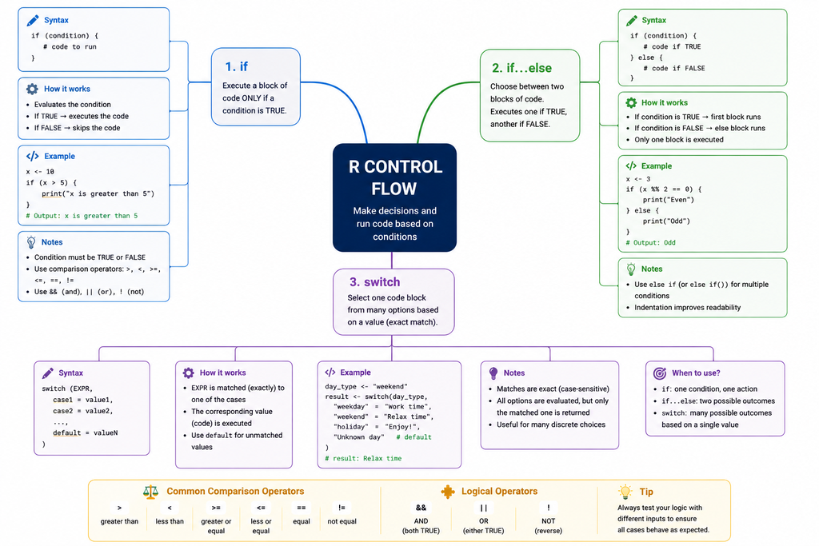

## R Loops

**Learning Purpose**

- Learn how to repeat tasks efficiently without writing the same code multiple times.
- Understand how loops automate repetitive operations in R.
- Control the execution of code across sequences and conditions.
- Use loops to process data step by step.
- Build a foundation for more advanced programming and data analysis tasks.

**Learning Objectives**

- Use for loops to iterate over sequences, vectors, and lists.
- Use while loops to repeat code as long as a condition remains TRUE.
- Use repeat loops for indefinite iteration with explicit stopping conditions.
- Apply next and break to control loop behavior.
- Write clear, efficient, and well-structured looping code in R.

## R Loops

- for Loop
- while Loop
- repeat Loop & break statement
- next statement

```r
v <- LETTERS[1:4]
#
for ( i in v) {
   print(i)
}
```

```
[1] "A"
[1] "B"
[1] "C"
[1] "D"
```

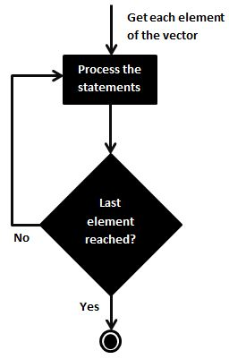

```r
v <- c("Hello","while loop")
cnt <- 2

while (cnt < 7) {
   print(v)
   cnt = cnt + 1
}
```

```
[1] "Hello"      "while loop"
[1] "Hello"      "while loop"
[1] "Hello"      "while loop"
[1] "Hello"      "while loop"
[1] "Hello"      "while loop"
```

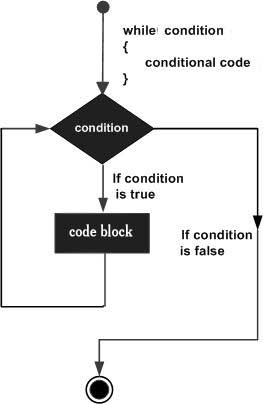

```r
v <- c("Hello","loop")
cnt <- 2

repeat {
   print(v)
   cnt <- cnt + 1

   if(cnt > 5) {
      break
   }
}
```

```
[1] "Hello" "loop"
[1] "Hello" "loop"
[1] "Hello" "loop"
[1] "Hello" "loop"
```

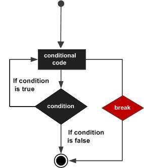

```r
v <- LETTERS[1:6]
for ( i in v) {

   if (i == "D") {
      next
   }
   print(i)
}
```

```
[1] "A"
[1] "B"
[1] "C"
[1] "E"
[1] "F"
```

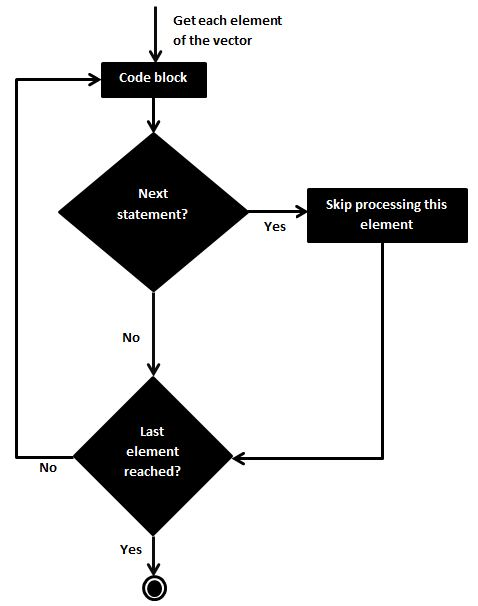

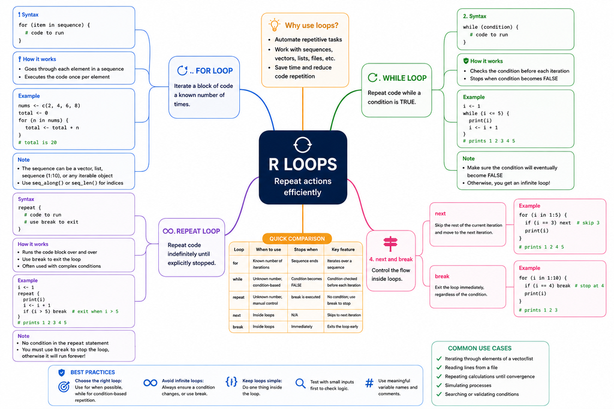

## The apply family

**Learning Purpose**

- Replace repetitive for-loops with simpler function-based operations
- Enable faster and more efficient data processing in R
- Perform operations on lists, vectors, matrices, and grouped data easily
- Improve code readability and reduce programming errors
- Support scalable and flexible data manipulation workflows

**Learning Objectives**

- Understand how to use apply-family functions instead of loops
- Identify which apply function fits different data structures (vector, list, matrix)
- Learn to apply functions across rows, columns, or groups efficiently
- Improve ability to write cleaner and more compact R code
- Develop basic functional programming thinking in R

## The apply family

An apply function is essentially a loop, but run faster than loops and often require less code. The apply family of functions is a set of functions in R that allow you to apply a function to the rows or columns of a matrix or data frame. The main functions in the apply family are:

- apply
- lapply
- sapply
- vapply
- tapply
- mapply

```r
mtrx <- matrix(c(1:10, 11:20, 21:30),
               nrow = 10, ncol = 3)
mtrx
```

```
      [,1] [,2] [,3]
 [1,]    1   11   21
 [2,]    2   12   22
 [3,]    3   13   23
 [4,]    4   14   24
 [5,]    5   15   25
 [6,]    6   16   26
 [7,]    7   17   27
 [8,]    8   18   28
 [9,]    9   19   29
[10,]   10   20   30
```

```r
apply(mtrx, 1, sum) # row-wise
```

```
 [1] 33 36 39 42 45 48 51 54 57 60
```

```r
apply(mtrx, 2, sum) # column-wise
```

```
[1]  55 155 255
```

```r
st.err <- function(x){
  sd(x)/sqrt(length(x))
}
apply(mtrx,2, st.err)
```

```
[1] 0.9574271 0.9574271 0.9574271
```

`lapply` is used to apply a function to each element of a list or vector and returns a list. It is useful when you want to apply a function to each element of a list and return the results in a list format.

```r
A<-c(1:10)
B<-c(11:20)
C<-c(21:30)
my.lst<-list(A,B,C)
```

```r
lapply(my.lst, sum)
```

```
[[1]]
[1] 55

[[2]]
[1] 155

[[3]]
[1] 255
```

`sapply` is a simplified version of `lapply`. It tries to simplify the result to a vector or matrix if possible.

```r
sapply(my.lst, mean)
```

```
[1]  5.5 15.5 25.5
```

`vapply` is similar to `sapply`, but it requires you to specify the type of output you expect. This can help prevent unexpected results.

```r
vapply(my.lst, mean, numeric(1))
```

```
[1]  5.5 15.5 25.5
```

`tapply` is used to apply a function to subsets of a vector, based on a grouping factor. It is useful for performing calculations on subsets of data.

```r
tapply(iris$Sepal.Length, iris$Species, mean)
```

```
    setosa versicolor  virginica
     5.006      5.936      6.588
```

`mapply` is a multivariate version of `sapply`. It allows you to apply a function to multiple arguments in parallel.

```r
A
```

```
 [1]  1  2  3  4  5  6  7  8  9 10
```

```r
B
```

```
 [1] 11 12 13 14 15 16 17 18 19 20
```

```r
C
```

```
 [1] 21 22 23 24 25 26 27 28 29 30
```

```r
mapply(sum, A, B, C)
```

```
 [1] 33 36 39 42 45 48 51 54 57 60
```

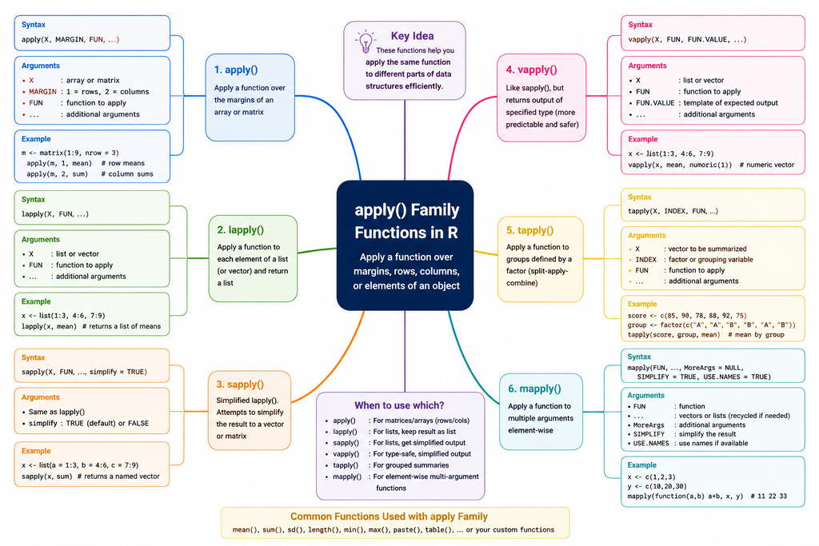